# Proyecto - P2

May 24th

# S2 Las clases híbridas en alumnos de 2° y 3° ciclo de UTEC en el periodo 2022-1

## Introducción

### Relevancia

- - - El desarrollo de este proyecto radica en el uso más recurrente del internet por parte de la comunidad de UTEC, sobre todo por el estudio, el cual se trasladó de las aulas a las plataformas como *Zoom* o *Google Meet*. Después de dos años, los alumnos están regresando gradualmente a las casas de estudio, en donde se ha dividido el alumnado entre los que irán presencialmente y virtualmente, a lo cual denominaron las clases híbridas.
    - No obstante, debido a este suceso, se ha podido observar y percibir diversas dificultades en esta alternativa de educación híbrida, tales como fallas en el audio de los profesores o la poca interacción de alumno virtual a comparación de un alumno presencial. Por lo tanto, es importante abordar este tema porque este estudio podrá ser una fuente de ayuda tanto para los mismos estudiantes como para el equipo técnico de UTEC para que así se pueda optimizar el aprendizaje y corregir errores que posiblemente se hayan podido pasar por desapercibidos.

### Objetivos

  - - **General:**
      - Determinar qué variables influyen en las dificultades de las clases híbridas en UTEC.
    - **Específicos:**
      - Analizar las dificultades de las clases híbridas.
      - Determinar el factor principal de las causas de nuestra problemática.
      - Conocer la situación emocional de la comunidad UTEC durante las clases.
      - Realizar una estimación de cuáles serían las condiciones ideales para que un estudiante se sienta estable y satisfecho con las clases híbridas.
      - Plantear soluciones para disminuir los problemas de las clases híbridas.
      - Estudiar qué relación tienen las variables entre sí, mediante los descriptores estadísticos (numéricos y gráficos).
      - Comparar las diferencias que tienen las variables y sus respectivos comportamientos.

### Planificación

#### Diagrama de Gantt

En primer lugar, establecemos una paleta de colores para lograr una armonía cromática en nuestro informe

```r
Pal_colores <- c(
  rgb(62, 95, 138, maxColorValue = 255),
  rgb(87, 131, 188, maxColorValue = 255),
  rgb(106, 156, 222, maxColorValue = 255),
  rgb(160, 197, 247, maxColorValue = 255),
  rgb(202, 223, 251, maxColorValue = 255),
  rgb(208, 229, 244, maxColorValue = 255))
```

```r
library(ggplot2)
library(tidyr)
library(lubridate)
df <- data.frame(Stage = c("J) Búsqueda y selección de 3 posibles temas","I)  Pre-entrega del proyecto" , "H) Elección del tema y elaboración de la encuesta", "G) Recolección de datos","F) Limpieza de datos y elaboración de la introducción","E) Elaboración del Diagrama de Gantt, descriptores y R presentation","D) P1-Entrega del proyecto","C) P2-Segunda entrega del proyecto","B) Correccción de entregas previas del proyecto"," A) Elaboración de modelos estadísticos")
                 , Start = c("2022-03-28", "2022-03-28"
                           , "2022-04-10", "2022-04-22"
                           , "2022-04-27", "2022-05-04"
                           , "2022-04-08", "2022_04-19"
                           ,"2022-05-23","2022-05-27")

                 ,End = c("2022-04-02","2022-04-08"
                          , "2022-04-15", "2022-04-29"
                          , "2022-05-04", "2022-05-08"
                          , "2022-05-06", "2022-06-24"
                          ,"2022-06-22","2022-06-22")
                 , Complete = c(TRUE, TRUE, TRUE , TRUE , TRUE , TRUE , TRUE , TRUE, TRUE,TRUE))

df$Start <- ymd(df$Start)
df$End <- ymd(df$End)

df.melt <- df%>%
  tidyr::pivot_longer(col = c(Start,End))
```

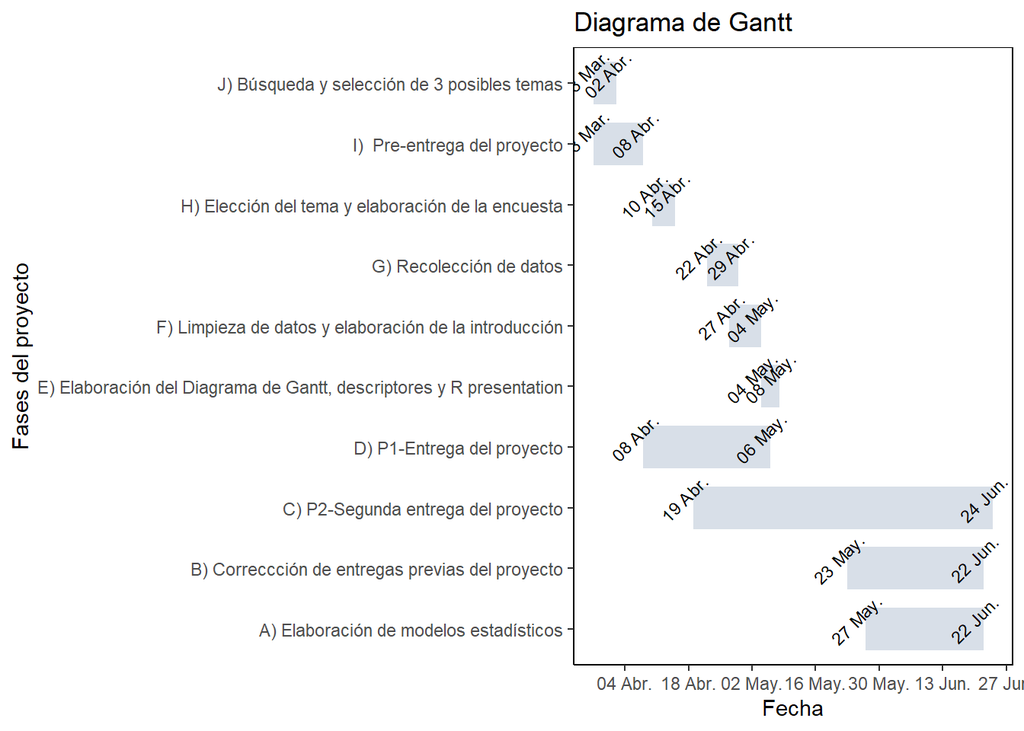

```r
pl <- ggplot(df.melt, aes(x = value, y = Stage, colour = Complete ))
pl <- pl + geom_line( alpha = 0.2, size = 10)
pl <- pl + geom_text(aes(label = format(value, "%d %b")), vjust = -0.5, angle = 45, size = 3, color = "black")
pl <- pl +   theme_classic()
pl <- pl + labs(title = "Diagrama de Gantt")
pl <- pl + labs(x = "Fecha")
pl <- pl + labs(y = "Fases del proyecto")
pl <- pl + scale_color_manual(values = c(Pal_colores[1], Pal_colores[1]))
pl <- pl + theme(legend.position = "write")
pl <- pl + theme(panel.background = element_rect(color = "black"))
pl <- pl + scale_x_date(name = "Fecha"
                        ,  date_labels = "%d %b"
                        ,  date_breaks = "2 week"
                        , minor_breaks = "1 day")
pl
```

## Datos

### Recolección de datos

- - - Los datos fueron obtenidos mediante una encuesta bien planteada en la plataforma “Formularios de Google”, ya que el equipo consideró que es una herramienta sencilla para manejar los datos y práctica para que nuestros encuestados puedan usar. Cabe resaltar que se tomó en cuenta que nuestra población contenga solamente alumnos de segundo y tercer ciclo de la UTEC que cuenten con acceso a internet para poder acceder a nuestro formulario y por lo menos posean un dispositivo electrónico, debido a que estos son requisitos para que puedan llevar sus clases virtuales.
    - Además , nos aseguramos un alto porcentaje de llenado correcto por parte de los alumnos ya que se colocó, en la mayoría de preguntas, respuestas con opciones para marcar y en las que se escribían pusimos ejemplos, siendo esto un factor importante para un buen llenado y de beneficio para nosotros a la hora de hacer la limpieza. Es relevante mencionar que hemos conseguido llegar a una muestra de 206 estudiantes con la estrategia de ingresar a grupos de estudio de segundo y tercer ciclo compartiendo el enlace de la encuesta. De la misma manera, hicimos la petición a los mentores para que lo compartan con sus *mentees* de estos ciclos pidiéndoles que realicen la encuesta. Finalmente, en cada petición de llenado se hizo el pedido de un llenado limpio y veraz, como así también se motivó el llenado por la realización de un sorteo de entradas dobles al cine y los estudiantes se animen.

### Población, muestra y muestreo

  - - En la elaboración del proyecto hemos decidido trabajar con la población de los **estudiantes de todas las carreras del segundo y tercer ciclo de UTEC en el mes de abril y año 2022**, siendo la unidad muestral cada estudiante que estudia en el presente semestre. Asimismo, el tamaño de nuestra muestra es de **206 estudiantes**, de los cuales hemos recolectado sus datos e información acerca de nuestro tema elegido, mediante una encuesta de Google Forms. Finalmente, nuestro **muestreo** es **por conveniencia**, debido a que hemos recaudado información de manera directa a algunos estudiantes de la muestra de la población y ellos decidían si dar o no la encuesta, para así fomentar la representatividad con información veraz.

### Variables de estudio

[output not shown]

### Limpieza de base de datos

- Analizando nuestra base de datos encontramos algunos errores, para ello empezamos llamando a las librerías que utilizaremos.

```r
library(readr)
library(dplyr)
```

Cargamos nuestro *dataframe* y asignamos manualmente el tipo y escala a cada una de nuestras 20 variables **iniciales**:

```r
CH <- read_csv("Clases_Hibridas_24.csv", col_types = "cccncnccncncccnncnnn")
```

Con ayuda de `select`, sacaremos de nuestro *dataframe* las primeras 3 variables porque son irrelevantes para nuestro estudio y se creará un subconjunto con 17 variables y será nuestro nuevo `CH`.

```r
select(CH, 4:20) -> CH
```

```r
CH <- rename(CH,
       Cal_inter_h = `Calidad de Internet del hogar`,
       Cal_clas_hib = `Calidad de las clases híbridas`,
       Equi_dispo = `¿Con qué equipos cuentas?`,
       Modalidad = `¿En qué modalidad prefieres asistir?`,
       Opi_moda = `¿Cómo consideras la modalidad de asistencia?`,
       Opi_aulashibri = `¿Cómo consideras las equipación de las aulas híbridas   en UTEC?`,
       Horas_presen = `Cantidad de horas semanales promedio que asistes a la universidad según el grupo que te corresponde (A-B) de manera presencial`,
Cal_lab = `Calidad de Laboratorios`,
Cal_docentes =`Calidad de enseñanza de los docentes`,
Horas_clas_virt = `Horas de clase virtual a la semana`,
Prom_gene = `Promedio general del ciclo regular anterior`)
```

Para nuestra variable `Periodo` hemos definido una sola nomenclatura la cual no tendrá espacio, se usará el punto como separador y solo se verificará que sean números arábigos)

```r
CH %>% mutate(Periodo =
        ifelse(Periodo %in% c("2021-I", "2021.1", "2021_1"), "2021-1",
        ifelse(Periodo %in% c("2021-II", "2021.2", "2021_2", "2021_ll"), "2021-2",
        Periodo
        ))) -> CH
```

En nuestra variable `Residencia`, podemos ver que las opciones son muy largas, entonces quitaremos las especificaciones de cada una estas, quedando así nombres más manejables.

```r
CH$Residencia[CH$Residencia=="Norte (Ancón, Pte. Piedra, Sta. Rosa, Carabayllo, Comas, Los Olivos, Independencia, S. M. Porres)"]<- "Norte"

CH$Residencia[CH$Residencia=="Sur (S. J. de Miraflores, V. M. de Triunfo, Villa el Salvador, Lurín y Pachacamac)" ]<- "Sur"

CH$Residencia[CH$Residencia=="Central Sur (Barranco, Miraflores, Surco, San Borja, Surquillo, San Isidro, Chorrillos)"]<- "Central Sur"

CH$Residencia[CH$Residencia=="Central (Cercado, San Luis, Breña, La Victoria, Rímac, Lince, San Miguel, Jesús María, Magdalena, Pueblo Libre)"]<- "Central"

CH$Residencia[CH$Residencia=="Balnearios del Sur (Pta. Hermosa, Pucusana, Pta. Negra, San Bartolo, Sta. María)"]<- "Balnearios del sur"

CH$Residencia[CH$Residencia=="Este (S. J. de Lurigancho, Sta. Anita, Cieneguilla, Ate Vitarte, La Molina, Chaclacayo, Lurigancho, El Agustino)"]<- "Este"
```

Determinamos el número de casos completos y observamos que nuestra `dataframe` cuenta con un 100% de casos completos (100%)

```r
# Número de casos completos
sum(complete.cases(CH))
```

```
## [1] 206
```

```r
# Porcentaje de casos completos
sum(complete.cases(CH))/nrow(CH)*100
```

```
## [1] 100
```

## Análisis descriptivo

- Podemos avanzar con este análisis porque no contamos con datos/casos incompletos por lo que nuestras gráficas serán eficientes y no tendrán interferencias.

–> *Calidad de Internet en el hogar de los alumnos*

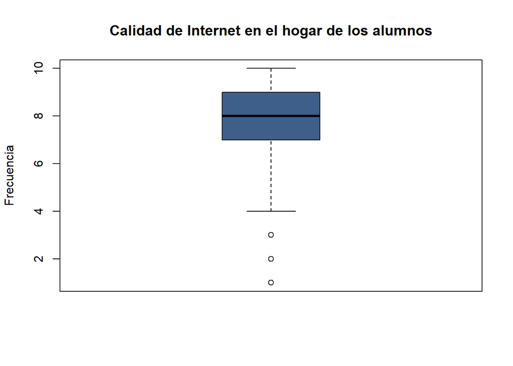

```r
 boxplot(CH$Cal_inter_h,
        main = "Calidad de Internet en el hogar de los alumnos",
        ylab = "Frecuencia",
        boxwex = 0.5,col=Pal_colores[1])
```

A partir del resultado de nuestro *boxplot* obtuvimos que aproximadamente **3 datos** de la variable `Cal_inter_h` son **atípicos**, es decir, tienen valores significativamente diferentes respecto a los demás datos, por lo que no es viable calcular el promedio o media aritmética.

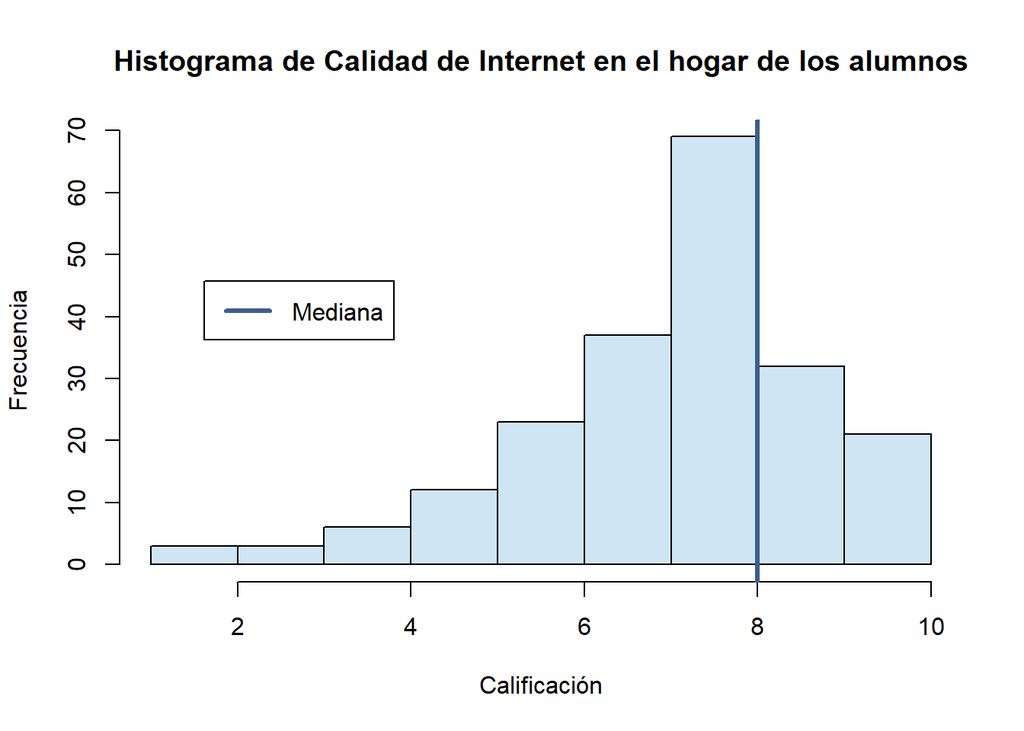

```r
hist(CH$Cal_inter_h,col = Pal_colores[6],main = "Histograma de Calidad de Internet en el hogar de los alumnos",xlab ="Calificación",ylab = "Frecuencia")
abline(v=median(CH$Cal_inter_h),col=Pal_colores[1],lwd=3)
legend("topleft", legend = "Mediana", col = Pal_colores[1], lty = 1, lwd = 3, inset = c(0.1, 0.35))
```

En esta gráfica podemos apreciar el comportamiento que hay en torno a la calificación del nivel de calidad de internet en el hogar de los estudiantes. Podemos observar que está sesgada a la izquierda por ello tiene una asimetría negativa; además, se observa que una mediana se ubica en la calificación 8 y que, al tener datos atípicos, esto origina que no se pueda obtener el promedio por ser un descriptor no robusto (sensible a los cambios). Este análisis es importante debido a que podemos apreciar que no habrían muchas interferencias respecto a la velocidad del internet en sus hogares ya que, al menos la mitad de los estudiantes le ha dado al menos valores mayores o iguales a 8 a esta variable.

–> *Calidad de enseñanza de los docentes*

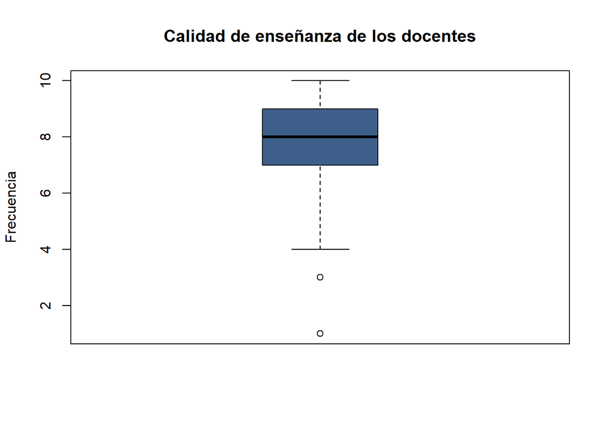

```r
 boxplot(CH$Cal_docentes,
        main = "Calidad de enseñanza de los docentes",
        ylab = "Frecuencia",
        boxwex = 0.5,col=Pal_colores[1])
```

A partir del resultado de nuestro *boxplot* obtuvimos que aproximadamente **2 datos** de la variable `Cal_docentes` son **atípicos**, es decir, tienen valores significativamente diferentes respecto a los demás datos, por lo que no es viable calcular el promedio o media aritmética pero sí los otros descriptores de posición.

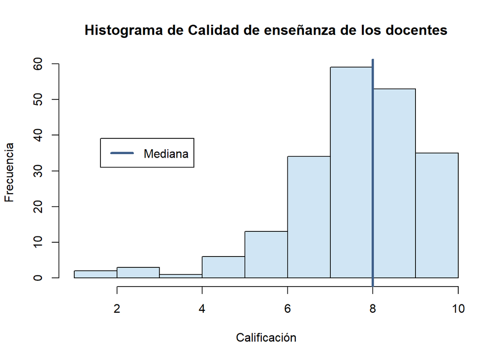

```r
hist(CH$Cal_docentes,col = Pal_colores[6],main = "Histograma de Calidad de enseñanza de los docentes",xlab ="Calificación",ylab = "Frecuencia")
abline(v=median(CH$Cal_docentes),col=Pal_colores[1],lwd=3)
legend("topleft", legend = "Mediana", col = Pal_colores[1], lty = 1, lwd = 3, inset = c(0.1, 0.35))
```

–> *Promedio General del ciclo anterior*

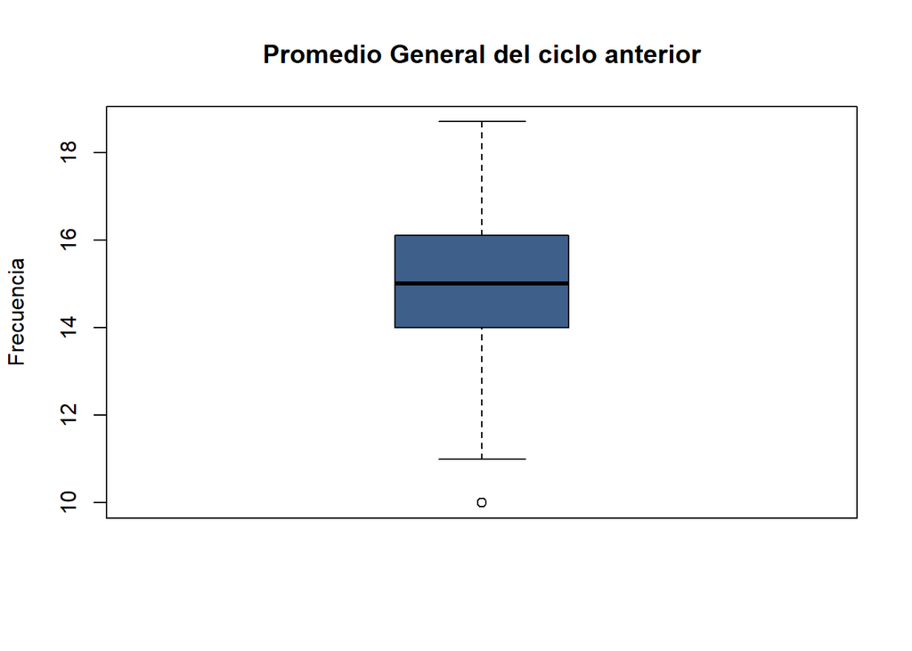

```r
 boxplot(CH$Prom_gene,
        main = "Promedio General del ciclo anterior",
        ylab = "Frecuencia",
        boxwex = 0.5,col=Pal_colores[1])
```

A partir del resultado de nuestro *boxplot* obtuvimos que aproximadamente **1 dato** de la variable `prom_gene` es **atípicos**, es decir, tienen valores significativamente diferentes respecto a los demás datos, por lo que no es viable calcular el promedio o media aritmética pero sí los otros descriptores de posición.

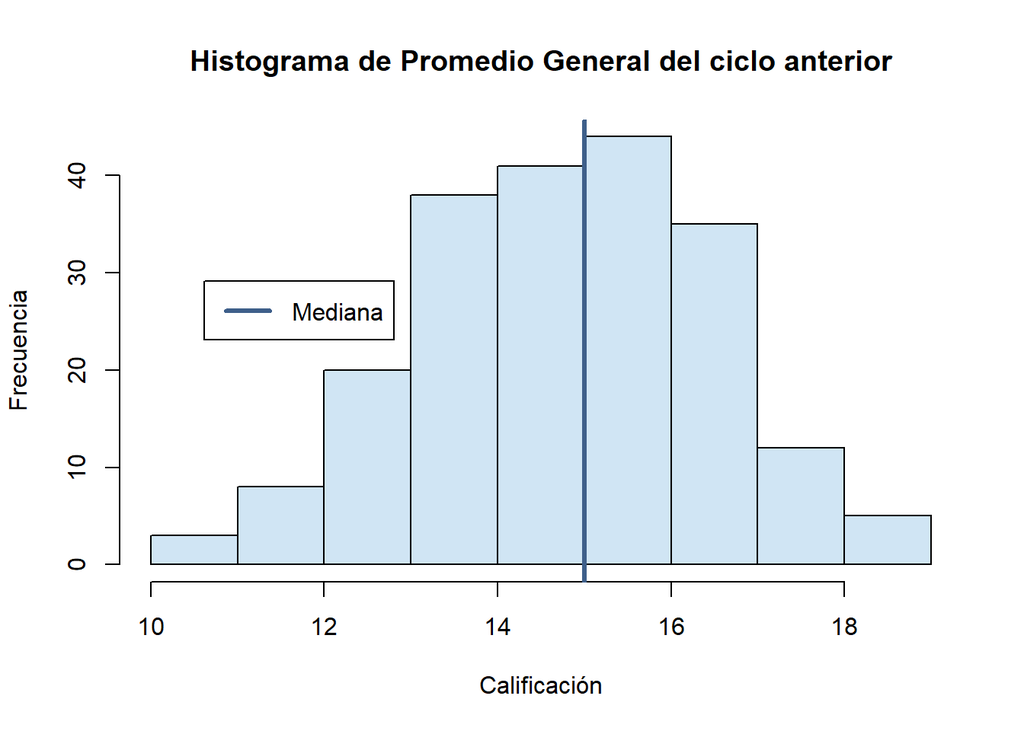

```r
hist(CH$Prom_gene,col = Pal_colores[6],main = "Histograma de Promedio General del ciclo anterior",xlab ="Calificación",ylab = "Frecuencia")
abline(v=median(CH$Prom_gene),col=Pal_colores[1],lwd=3)
legend("topleft", legend = "Mediana", col = Pal_colores[1], lty = 1, lwd = 3, inset = c(0.1, 0.35))
```

En la elaboración de este tercer gráfico hemos tenido en cuenta la importancia de tener conocimiento el promedio general de los estudiantes obtenidos debido a que esto es un indicador de cómo les ha estado yendo en estas clases. Estando la mediana en el valor de 15, si observamos detenidamente el gráfico mostrado, podemos observar que a la mayoría de estudiantes les está yendo bien en estas modalidades nuevas de estudio implantados por la universidad.

–> *Promedio obtenido según la calificación a los profesores*

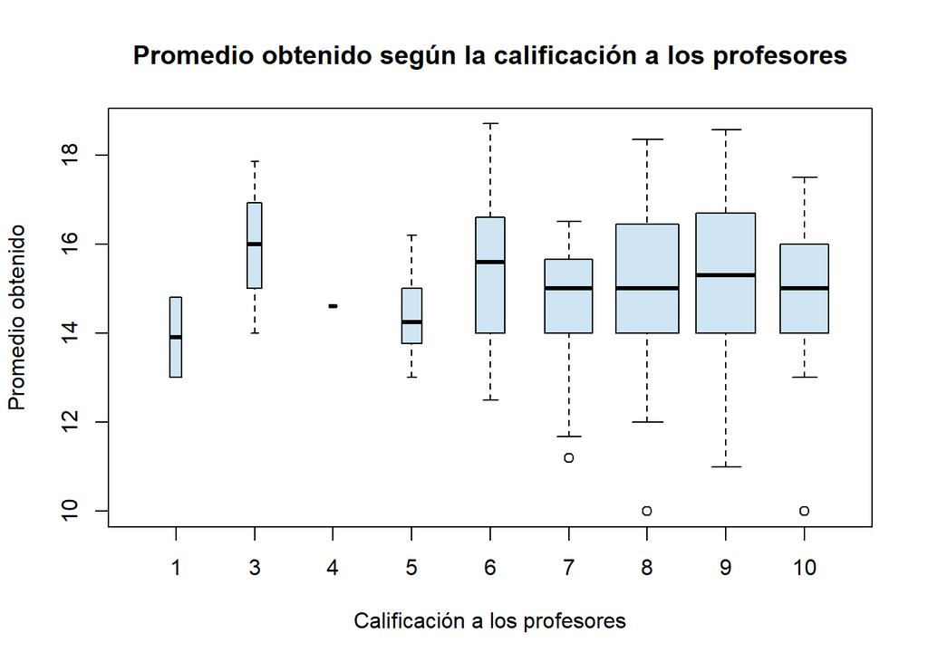

```r
boxplot((CH$Prom_gene) ~ CH$Cal_docentes, varwidth=TRUE, main="Promedio obtenido según la calificación a los profesores", ylab="Promedio obtenido", xlab = "Calificación a los profesores", col=c(Pal_colores[6]))
```

–> *Horas de asistencia presencial según el lugar de residencia*

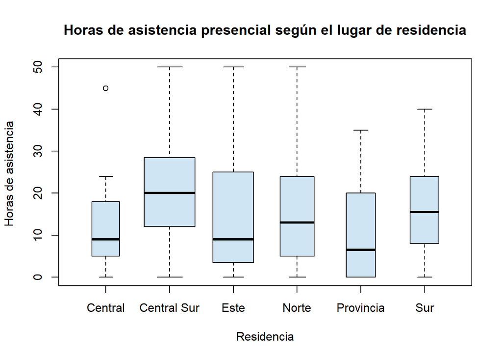

```r
boxplot((CH$Horas_presen) ~ CH$Residencia, varwidth=TRUE, main="Horas de asistencia presencial según el lugar de residencia", ylab="Horas de asistencia ", xlab = "Residencia", col=c(Pal_colores[6]))
```

En la elaboración del 5to gráfico se puede apreciar la relación coherente de las dos variables de `Horas_presen` con `Residencia`. Entonces podemos ver la tendencia en asistencia a la universidad según el lugar donde vive el estudiante y deducir según ello que los estudiantes que son de la parte Central Sur son en promedio los que asisten más de manera presencial y del modo contrario podemos afirmar que la menor cantidad de asistencia de manera presencial son los estudiantes que son de Provincia por lógicas razones.

–> *Horas de asistencia presencial a la semana según el ciclo*

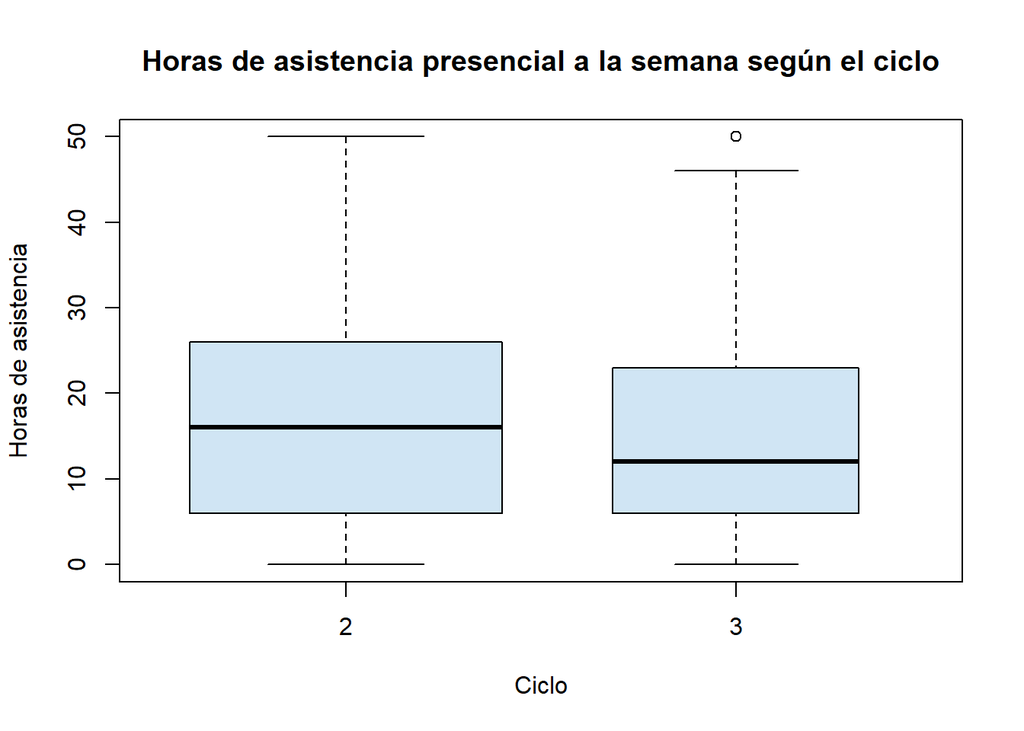

```r
boxplot(CH$Horas_presen~CH$Ciclo,main="Horas de asistencia presencial a la semana según el ciclo", xlab ="Ciclo" , ylab = "Horas de asistencia", col=c(Pal_colores[6]),varwidth=TRUE)
```

En este gráfico estamos relacionando las variables `Horas_presen` y el `Ciclo` en el que se encuentra el estudiante, en este caso nuestra investigación se basó en chicos que cursan el segundo y tercer ciclo en la UTEC . Podemos observar según la mediana, que está representada en el diagrama de caja como una línea horizontal gruesa, que los alumnos del segundo ciclo asisten más horas en promedio que los del tercer ciclo, esto se podría dar debido a que comparten cursos básicos con sus grupos y se apoyan entre sí comparado a los de tercer ciclo que ya van avanzando con cursos de carrera y tienen menos tiempo de ir por la complejidad de los cursos que llevan. Además, se evidencia que más del 50% de alumnos en el segundo ciclo asisten de manera presencial en un rango de 5 a 25 horas aproximadamente a diferencia de los del tercer ciclo que asisten en un rango de 5 a 22 horas por semana aproximadamente.

## Análisis probabilístico

### Sobre variables discretas

-> *Análisis del promedio general del ciclo anterior* Para ello se va determinar que tipo que forma de gráfico nos muestra, mediante un gráfico de barras.

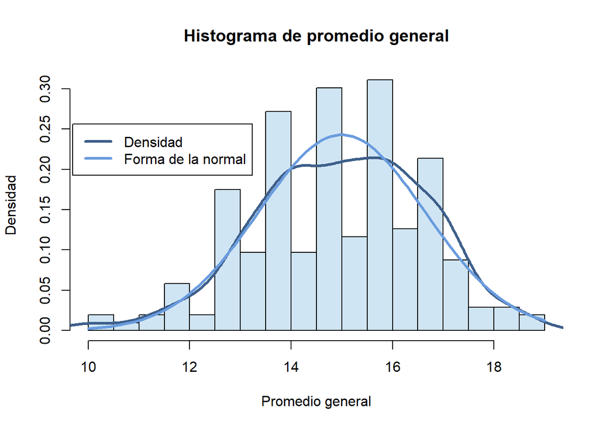

```r
hist(CH$Prom_gene,breaks=18, freq= F,main="Histograma de promedio general", ylab="Densidad", xlab = "Promedio general", col=Pal_colores[6])
lines(density(CH$Prom_gene, na.rm=T), col=Pal_colores[1],lwd=3)
curve(dnorm(x, mean(CH$Prom_gene, na.rm=T), sd(CH$Prom_gene, na.rm=T)), lwd=3, col=Pal_colores[3],add=T)
legend("topright", legend = c("Densidad", "Forma de la normal"), col = c(Pal_colores[1], Pal_colores[3]), lty = 1, lwd = 3, inset = c(0.63, 0.20))
```

Para ello necesitamos la media y la desviación estándar

```r
# Media

l<-mean(CH$Prom_gene)
l
```

```
## [1] 14.99816
```

```r
# Desviación estándar

m<-sd(CH$Prom_gene)
m
```

```
## [1] 1.642921
```

**Aplicación de la desviación estándar**

La nota media de los alumnos del segundo y tercer ciclo de UTEC es de 14.99816, con un desviación estándar de 1.642921; si su nota esta distribuido normalmente, ¿qué porcentaje de alumnos tendrá una nota de 15 a 20 de calificación?.

$P(15\leq x \leq 20)$

```r
p<-pnorm(20, mean =14.66658 ,sd= 14.99816)-pnorm(15, mean = 15, sd=1.642921)
p
```

```
## [1] 0.1389318
```

```r
l<-pnorm(0:20, mean =14.66658 ,sd= 14.99816)-pnorm(15, mean = 15, sd=1.642921)
```

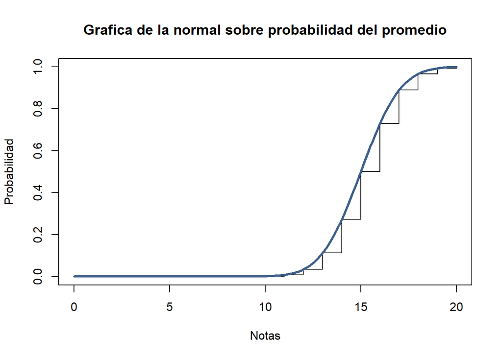

```r
Xs<-seq(0,20, by=0.1)
plot(0:20,pnorm(0:20, mean=14.99816 ,sd= 1.642921), type = "s", main="Grafica de la normal sobre probabilidad del promedio", xlab = "Notas", ylab="Probabilidad")
lines(Xs, pnorm(Xs, mean=14.99816 , sd=1.642921), col=Pal_colores[1],lty = 1, lwd = 3)
```

-> *Análisis de los tipos de modalidad que prefieren asistir los estudiantes de segundo y tercer ciclo de la UTEC*

Para ello se va determinar la probabilidad de que suceda cada una de las modalidades que prefieren asistir mediante un gráfico de barras que este expresado respecto a la probabilidad.

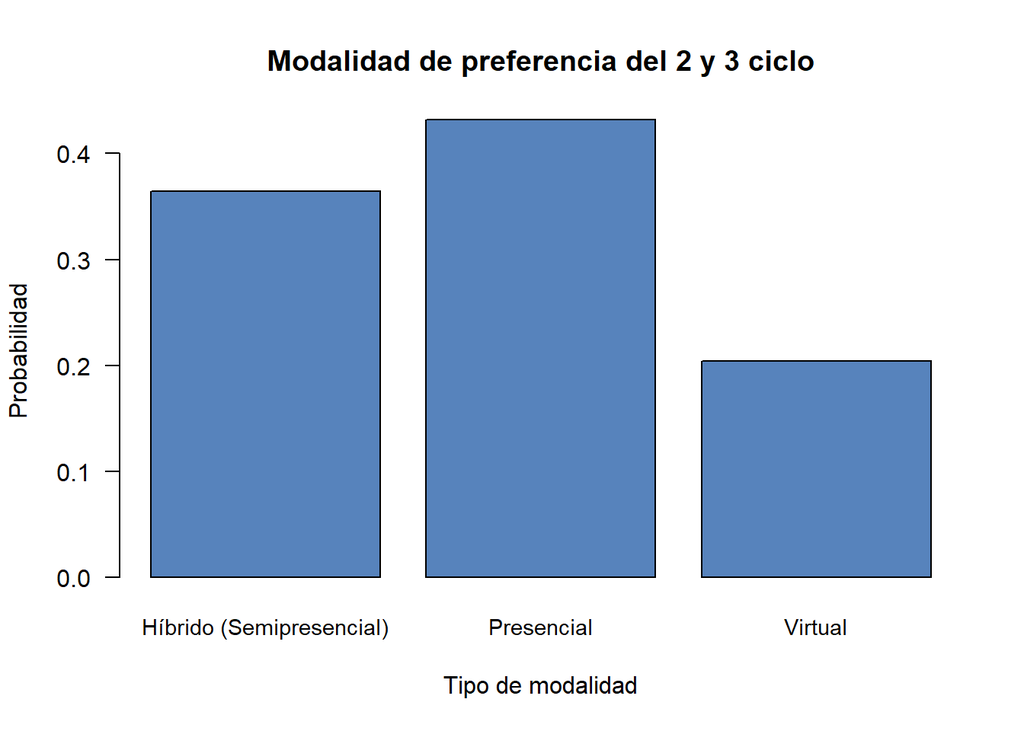

```r
barplot(prop.table(table(CH$Modalidad)), main = "Modalidad de preferencia del 2 y 3 ciclo", ylab = "Probabilidad",xlab = "Tipo de modalidad",cex.names = 0.9, las=1, col = Pal_colores[2])
```

Para obtener ver los valores de manera explícita de las probabilidades lo vamos a expresar en tablas.

```r
table(CH$Modalidad)
```

```
##
## Híbrido (Semipresencial)               Presencial                  Virtual
##                       75                       89                       42
```

```r
mod_asis <- prop.table(table(CH$Modalidad))
mod_asis <- data.frame(mod_asis)
names(mod_asis)[names(mod_asis)=='Freq'] <- 'Probabilidad'
mod_asis
```

| Var1 | Probabilidad |
| --- | --- |
| Híbrido (Semipresencial) | 0.3640777 |
| Presencial | 0.4320388 |
| Virtual | 0.2038835 |

**Aplicación #1:** Mediante una encuesta a 206 alumnos entre el segundo y tercer ciclo de la UTEC, se sabe que los resultados de la encuesta son de 89 prefieren asistir de manera presencial, 42 virtual y 75 híbrido, si la probabilidad de que asistan de manera presencial es de 0.4320388.

Calcular la probabilidad de que 20 alumnos de 89 prefirieran asistir de forma presencial: éxito-> alumnos que asistan de manera presencialmente: 0.4320388  
fracaso-> alumnos prefieran híbrido o virtual: 0.2038835+0.3640777 variable aleatoria–> Numero de alumnos que prefieren asistir a clases presenciales. $P(X=20)$-> valor único se llama función de masa”d” dbinom(numero de éxitos, tamaño, probabilidad de éxito)

```r
dbinom(20,89,0.4320388)
```

```
## [1] 2.273551e-05
```

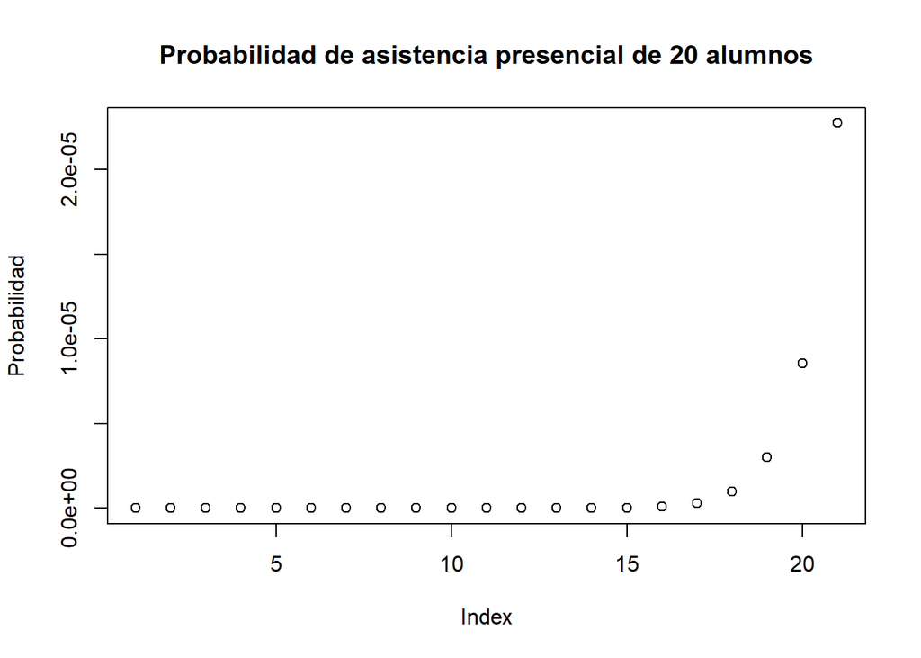

```r
plot(dbinom(c(0:20),89,0.4320388), main = "Probabilidad de asistencia presencial de 20 alumnos",ylab = "Probabilidad") ##distribución de Gauss
```

```r
dbinom(32,75,0.2038835)
```

```
## [1] 6.847227e-06
```

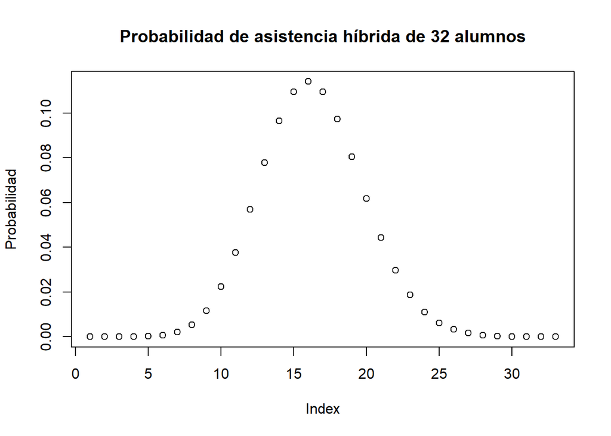

```r
plot(dbinom(c(0:32),75,0.2038835), main = "Probabilidad de asistencia híbrida de 32 alumnos",ylab = "Probabilidad") ##distribución de Gauss
```

```r
dbinom(19,42,0.3640777)
```

```
## [1] 0.06181159
```

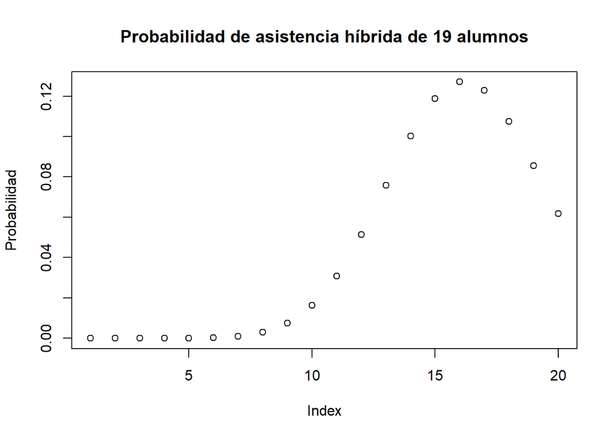

```r
plot(dbinom(c(0:19),42,0.3640777), main = "Probabilidad de asistencia híbrida de 19 alumnos",ylab = "Probabilidad") # Distribución de Gauss
```

-> *Analizando las horas de clases virtuales*

```r
m<-sort(desc(table(CH$Horas_clas_virt)))
```

[figure not shown]

```r
barplot(prop.table(m), main = " Calidad de internet respecto a su residencia según los estudiantes", ylab = "Probabilidad",cex.names =  0.9, las=1 , xlab="Cantidad de horas de clases virtuales", col=Pal_colores[6])
```

En la gráfica podemos determinar que los datos siguen un modelo exponencial para lo cual vamos a calcular los parámetros.

Se va calcular el valor de beta, el cual viene a ser la media:

```r
LL3<-mean(CH$Horas_clas_virt)
LL3
```

```
## [1] 10.87379
```

El parámetro que se usa en el modelo exponencial es lambda, el cual es la inversa de beta o media.

```r
DD3<-1/LL3
DD3
```

```
## [1] 0.09196429
```

El valor de lambda(*λ*) es 0.09196429

Con los parámetros obtenidos podemos representar la función exponencial, añadiendo a la gráfica anterior.

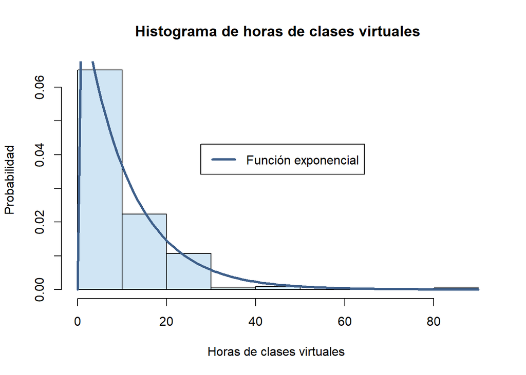

```r
hist(CH$Horas_clas_virt, probability = 1 , freq= F,main="Histograma de horas de clases virtuales", ylab="Probabilidad", xlab = "Horas de clases virtuales ", col=Pal_colores[6])
curve(dexp(x, DD3), lwd=3, col=Pal_colores[1],add=TRUE)
legend("topright", legend = c("Función exponencial"), col = c(Pal_colores[1]), lty = 1, lwd = 3, inset = c(0.3, 0.35))
```

## Bibliografía

- - D.-J.L. (2019, marzo). Introducción al software estadístico R. Curso de formación en R. https://idaejin.github.io/courses/R/2019/euskaltel/
  - Facultad de Enfermería, & Beatriz Pateiro, P. F. (2013). Tema 1. Estadística Descriptiva (N.o 15). http://eio.usc.es/eipc1/BASE/BASEMASTER/FORMULARIOS-PHP-DPTO/MATERIALES/Mat_G2021103104_EstadisticaTema1.pdf
  - González, J. J., & Guerra, N. (s. f.). PROBABILIDAD. Métodos Estadísticos. https://www2.ulpgc.es/hege/almacen/download/28/28313/temaprobabilidad.pdf
  - Introducción a la programación básica con R. (2019). En Cursos de formación en R (capitulo 4 ed., p. 4). GNU-GPL. https://idaejin.github.io/courses/R/2019/euskaltel/introduccion-a-la-programacion-basica-con-r.html
  - Introducción al software estadístico R. (2019). En Curso de formacion en R (capitulo 2 ed., pp. 2–3). GNU-GPL. https://idaejin.github.io/courses/R/2019/euskaltel/intro.html
  - Jin Lee, D. (Ed.). (2019). Análisis de datos básico en R. En Introducción al software estadístico R (capitulo 3 ed., p. 3). A MUST. https://idaejin.github.io/courses/R/2019/euskaltel/basic.html
  - Jin Lee, D. (Ed.). (2019b). Distribuciones de probabilidad en R. En Curso y formación en R (capitulo 5 ed., p. 5). GNU-GPL. https://idaejin.github.io/courses/R/2019/euskaltel/distribuciones-de-probabilidad-en-r.html
  - Jin Lee, D. (Ed.). (2019c). Modelos lineales y análisis de la varianza. En Curso de formación en R (capitulo 6 ed., pp. 6–6-7). GNU-GPL. https://idaejin.github.io/courses/R/2019/euskaltel/modelos-lineales-y-analisis-de-la-varianza.html
  - Paredes Inilupu, M. D. (2020, 26 junio). Análisis de Datos y algoritmos de predicción con R. Data Science con R. https://bookdown.org/dparedesi/data-science-con-r/
  - Universidad de Puerto Rico en Bayamón Departamento de Matemáticas. (2010, junio). PROBABILIDAD (10 mo – 12 mo). http://docs.uprb.edu/deptmate/material%20suplementario/CIME/10mo%20a%2012mo/T6%3B%20Probabilidad%2810mo%20a%2012mo%29.pdf